```r
library(tidyverse)
```

*2. Battery Life*

**a) Read in and display the data.**

```r
my_url <- "http://ritsokiguess.site/STAD29/batteries.txt"
battery <- read_delim(my_url, " ")
battery
```

```
## # A tibble: 36 x 3
##    material temperature life_hours
##    <chr>    <chr>            <dbl>
##  1 A        low                130
##  2 A        low                155
##  3 A        low                 74
##  4 A        low                180
##  5 A        medium              34
##  6 A        medium              40
##  7 A        medium              80
##  8 A        medium              75
##  9 A        high                20
## 10 A        high                70
## # … with 26 more rows
```

Variables: response = life_hours, explanatory = material, temperature

**b) Which order are the temperatures in, as far as R is concerned? Does that make sense? If not, put them in the right order by creating a column in the data frame that has the right order.**

```r
battery %>%
mutate(temp2=fct_inorder(temperature)) -> battery
battery
```

```
## # A tibble: 36 x 4
##    material temperature life_hours temp2
##    <chr>    <chr>            <dbl> <fct>
##  1 A        low                130 low
##  2 A        low                155 low
##  3 A        low                 74 low
##  4 A        low                180 low
##  5 A        medium              34 medium
##  6 A        medium              40 medium
##  7 A        medium              80 medium
##  8 A        medium              75 medium
##  9 A        high                20 high
## 10 A        high                70 high
## # … with 26 more rows
```

The temperatures as far as R is concerned is in alphabetical order instead of logical order. This is because it is text form so I need to change it to factor.

**c) Make a suitable plot of these data, given the number and types of variables you have. Put temperature on the x-axis.**

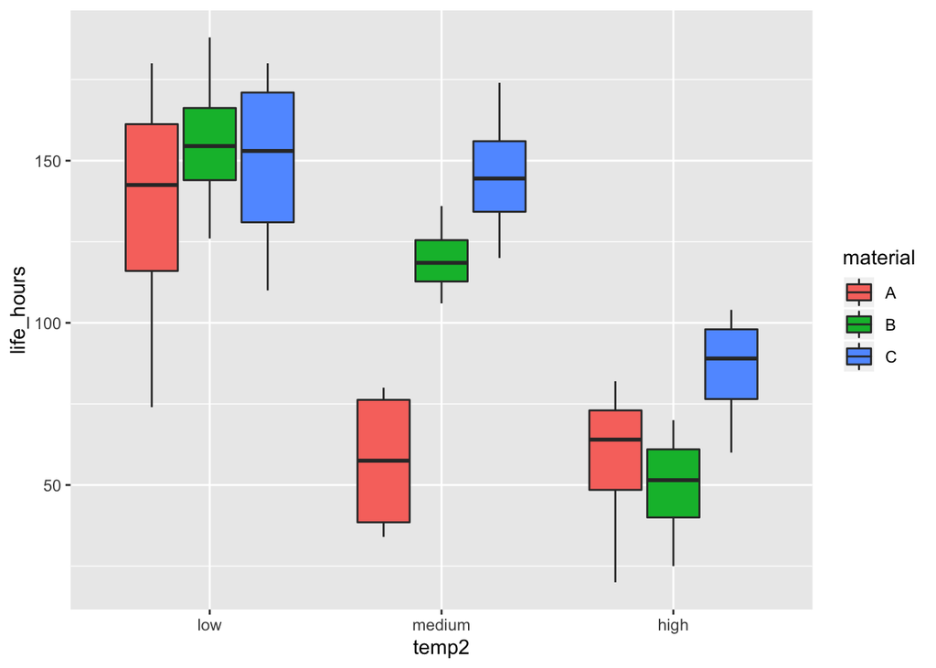

```r
ggplot(battery, aes(x = temp2, y = life_hours, fill = material)) + geom_boxplot()
```

Materials that were operated at a low temperature tend to operate for more hours than those operated at medium an high temperatures. Batteries that were made out of material C operate for more hours than materials A and B in high and medium temperatures.

**d) Make an interaction plot, again putting temperature on the x-axis.**

```r
summary <- battery %>%
  group_by(material, temp2) %>%
  summarize(mean = mean(life_hours))
summary
```

```
## # A tibble: 9 x 3
## # Groups:   material [3]
##   material temp2   mean
##   <chr>    <fct>  <dbl>
## 1 A        low    135.
## 2 A        medium  57.2
## 3 A        high    57.5
## 4 B        low    156.
## 5 B        medium 120.
## 6 B        high    49.5
## 7 C        low    149
## 8 C        medium 146.
## 9 C        high    85.5
```

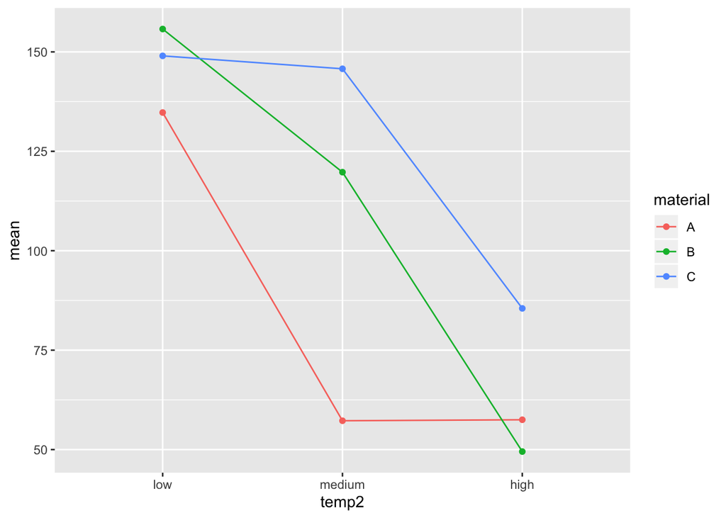

```r
g <- ggplot(summary, aes(x = temp2, y = mean, colour = material, group = material)) + geom_point() + geom_line()
g
```

**e) What do you conclude from your interaction plot? By looking at your first plot, explain briefly why your conclusions from your interaction plot makes sense.**

The three lines are not parallel so there should be an interaction between the temperature and the material. The conclusion from my interaction plot makes sense because the boxplots demonstrate that the number of hours that a battery operates depends on the material it is made of, and the temperature at which it was operated. It can be seen in the plot there are differences with the number of hours that the battery operates for within each temperature, as well some materials within each temperature operate for longer than other materials.

**f) Run a suitable analysis of variance, including interaction, and display the results. Was your interaction significant?**

```r
battery.1 <- aov(life_hours ~ material * temperature, data = battery)
summary(battery.1)
```

```
##                      Df Sum Sq Mean Sq F value  Pr(>F)
## material              2  11488    5744   8.090 0.00177 **
## temperature           2  40713   20357  28.670 2.1e-07 ***
## material:temperature  4   8843    2211   3.113 0.03143 *
## Residuals            27  19171     710
## ---
## Signif. codes:  0 '***' 0.001 '**' 0.01 '*' 0.05 '.' 0.1 ' ' 1
```

**g) Explain briefly why simple effects would be a useful technique for this data set, and give an example of a comparison you would make with them.**

Simple effects would be a useful technique here because we want to see the effects of one variable (material) conditional on another variable (temperature). We are not interested in all comparisons between material and temperature combinations. An example of a comparison you would make with them is the simple effects of temperature when the material is A to see when the material is A if there is an effect on temperature.

```r
battery %>%
  filter(material == "A") %>%
  aov(life_hours ~ temperature, data = .) -> simple_A
summary(simple_A)
```

```
##             Df Sum Sq Mean Sq F value Pr(>F)
## temperature  2  15965    7983   7.181 0.0137 *
## Residuals    9  10004    1112
## ---
## Signif. codes:  0 '***' 0.001 '**' 0.01 '*' 0.05 '.' 0.1 ' ' 1
```

**h) Find the simple effects of material at each temperature. That is, for each temperature, compare the materials at that temperature using aov and (if necessary) Tukey, and state your conclusions in the context of the data.**

```r
battery %>%
  filter(temperature == "low") %>%
  aov(life_hours ~ material, data = .) -> simple_low
summary(simple_low)
```

```
##             Df Sum Sq Mean Sq F value Pr(>F)
## material     2    920   459.8   0.373  0.699
## Residuals    9  11103  1233.7
```

When the temperature is low there is no effect on material.

```r
battery %>%
  filter(temperature == "medium") %>%
  aov(life_hours ~ material, data = .) -> simple_medium
summary(simple_medium)
```

```
##             Df Sum Sq Mean Sq F value   Pr(>F)
## material     2  16553    8276   20.26 0.000465 ***
## Residuals    9   3676     408
## ---
## Signif. codes:  0 '***' 0.001 '**' 0.01 '*' 0.05 '.' 0.1 ' ' 1
```

```r
TukeyHSD(simple_medium)
```

```
##   Tukey multiple comparisons of means
##     95% family-wise confidence level
##
## Fit: aov(formula = life_hours ~ material, data = .)
##
## $material
##     diff       lwr       upr     p adj
## B-A 62.5  22.59911 102.40089 0.0045670
## C-A 88.5  48.59911 128.40089 0.0004209
## C-B 26.0 -13.90089  65.90089 0.2177840
```

When the temperature is medium there is definately an effect of material. There is a difference in A but no difference in B and C.

```r
battery %>%
  filter(temperature == "high") %>%
  aov(life_hours ~ material, data = .) -> simple_high
summary(simple_high)
```

```
##             Df Sum Sq Mean Sq F value Pr(>F)
## material     2   2859  1429.3    2.93  0.105
## Residuals    9   4391   487.9
```

When the temperature is high there is no effect on material.

*3. Plant Experiment*

**a) Display the data set.**

```r
PlantGrowth
```

```
##    weight group
## 1    4.17  ctrl
## 2    5.58  ctrl
## 3    5.18  ctrl
## 4    6.11  ctrl
## 5    4.50  ctrl
## 6    4.61  ctrl
## 7    5.17  ctrl
## 8    4.53  ctrl
## 9    5.33  ctrl
## 10   5.14  ctrl
## 11   4.81  trt1
## 12   4.17  trt1
## 13   4.41  trt1
## 14   3.59  trt1
```

[output cut: 16 more lines]

**b) Make a suitable plot of the data.**

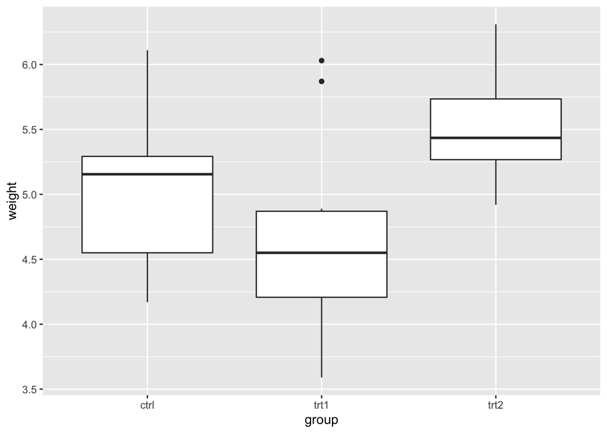

```r
ggplot(PlantGrowth, aes(x = group, y = weight)) + geom_boxplot()
```

The boxplot suggests that treatment 2 has a greater plant yield than the other 2 groups. However, the control group has a greater yield than treatment 1.

There are outliers present in the treatment 1 group and some right-skewness.

**c) Why is this a situation where contrasts would be helpful? Explain briefly.**

This is a situation where contrasts would be helpful because the researcher is not interested in all the comparisons between groups, but rather in two specific ones. The two specific hypotheses were: whether the average of the two treatments is different from the control, and whether the two treatments differ from one another.

**d) Set up contrasts for the two hypotheses of interest. That is, define two vectors with mnemonic names whose values reflect what you want to compare with what. (To get the order right, think about what order the treatment groups came out on your plot.)**

```r
PlantGrowth <- PlantGrowth %>% mutate(group = factor(group))
PlantGrowth %>% select(group) %>% summary()
```

```
##   group
##  ctrl:10
##  trt1:10
##  trt2:10
```

Treatment 1 vs. Treatment 2

```r
c.trt1.trt2 <- c(0, 1, -1)
```

Control against the average of the treatments: control - (treatment1 + treatment2)/2

```r
c.ctrl.others <- c(1, -0.5, -0.5)
```

**e) Demonstrate that your two contrasts are orthogonal.**

```r
sum(c.trt1.trt2 * c.ctrl.others)
```

```
## [1] 0
```

It adds up to 0 so it is orthogonal.

**f) Use your two contrasts to set up for lm to test them via summary.**

```r
m <- cbind(c.trt1.trt2, c.ctrl.others)
m
```

```
##      c.trt1.trt2 c.ctrl.others
## [1,]           0           1.0
## [2,]           1          -0.5
## [3,]          -1          -0.5
```

```r
contrasts(PlantGrowth$group) <- m
```

**g) Fit an appropriate model and display its summary.**

```r
PlantGrowth.1 <- lm(weight ~ group, data = PlantGrowth)
summary(PlantGrowth.1)
```

```
##
## Call:
## lm(formula = weight ~ group, data = PlantGrowth)
##
## Residuals:
##     Min      1Q  Median      3Q     Max
## -1.0710 -0.4180 -0.0060  0.2627  1.3690
##
## Coefficients:
##                    Estimate Std. Error t value Pr(>|t|)
## (Intercept)          5.0730     0.1138  44.573  < 2e-16 ***
## groupc.trt1.trt2    -0.4325     0.1394  -3.103  0.00446 **
## groupc.ctrl.others  -0.0410     0.1610  -0.255  0.80086
## ---
## Signif. codes:  0 '***' 0.001 '**' 0.01 '*' 0.05 '.' 0.1 ' ' 1
##
## Residual standard error: 0.6234 on 27 degrees of freedom
## Multiple R-squared:  0.2641, Adjusted R-squared:  0.2096
## F-statistic: 4.846 on 2 and 27 DF,  p-value: 0.01591
```

**h) What do you conclude? Explain briefly why that makes sense by looking at the plot you drew earlier.**

c.trt1.trt2 was the contrast between the two treatment groups. This is signifcant (P-value 0.00446). It is comparable to the plot that was drawn earlier because there was a visible difference between the two boxplots for treatment 1 and 2. Treatment 2 is better than treatment 1.

c.ctrl.others was the contrast between the control and the two treatments. This is not significant (P-value 0.80086). It is comparable to the plot that was drawn earlier because the control group was actually better than treatment 1 but not better than treatment 2.